# Wenjing Sun HW5

#data preparation

```r
rm(list = ls(all = TRUE))
library(sna)
library(data.table)
library(ergm)
library(network)
library(plyr)
data<-fread("startup_rounds_and_participants.csv",header=TRUE)

data$startup_id<-as.character(data$startup_id)
data$participant_id<-as.character(data$participant_id)

edge1<-data

# specify the network we'll call net - where dyads are the unit of analysis...
net=network(edge1[,c("participant_id", "startup_id")])

# assign edge-level attributes - dyad attributes
set.edge.attribute(net, "traction", edge1[,"traction"])
set.edge.attribute(net, "round", edge1[,"startup_round_id"])
set.edge.attribute(net, "date", edge1[,"round_record_date"])

# assign node-level attributes to actors in "net"
net %v% "participant_type" = edge1[,"participant_type"]
```

#Question 1 Use the network information provided and an ERGM model to predict whether reciprocation is more or less likely in this network. What if we only consider connections between startups? Why does the second model appear different? Include an edges intercept in both models.

```r
m1=ergm(net ~ edges + mutual,burnin=15000,MCMCsamplesize=30000,verbose=FALSE)
```

```
## Starting maximum likelihood estimation via MCMLE:
```

```
## Iteration 1 of at most 20:
```

```
## Optimizing with step length 1.
```

```
## The log-likelihood improved by < 0.0001.
```

```
## Step length converged once. Increasing MCMC sample size.
```

```
## Iteration 2 of at most 20:
```

```
## Optimizing with step length 1.
```

```
## The log-likelihood improved by 0.00022.
```

```
## Step length converged twice. Stopping.
```

```
## Evaluating log-likelihood at the estimate. Using 20 bridges: 1 2 3 4 5 6 7 8 9 10 11 12 13 14 15 16 17 18 19 20 .
## This model was fit using MCMC.  To examine model diagnostics and check for degeneracy, use the mcmc.diagnostics() function.
```

```r
summary(m1)
```

```
##
## ==========================
## Summary of model fit
## ==========================
##
## Formula:   net ~ edges + mutual
##
## Iterations:  2 out of 20
##
## Monte Carlo MLE Results:
##        Estimate Std. Error MCMC % p-value
## edges  -3.96321    0.04199      0  <1e-04 ***
## mutual  0.35901    0.37281      0   0.336
## ---
## Signif. codes:  0 '***' 0.001 '**' 0.01 '*' 0.05 '.' 0.1 ' ' 1
##
##      Null Deviance: 44170  on 31862  degrees of freedom
##  Residual Deviance:  5947  on 31860  degrees of freedom
##
## AIC: 5951    BIC: 5967    (Smaller is better.)
```

```r
exp(m1[1]$coef)
```

```
##     edges    mutual
## 0.0190021 1.4319066
```

```r
#only consider connections between startups
edge2<-edge1[,c("participant_id", "startup_id")][which(edge1[,"participant_type"]=="Startup"),]
net_start<-network(edge2)
# assign edge-level attributes - dyad attributes
set.edge.attribute(net_start, "traction", edge1[,"traction"])
set.edge.attribute(net_start, "round", edge1[,"startup_round_id"])
set.edge.attribute(net_start, "date", edge1[,"round_record_date"])

# assign node-level attributes to actors in "net"
net %v% "participant_type" = edge1[,"participant_type"]
m2=ergm(net_start~ edges + mutual ,burnin=15000,MCMCsamplesize=30000,verbose=FALSE)
```

```
## Starting maximum likelihood estimation via MCMLE:
```

```
## Iteration 1 of at most 20:
```

```
## Optimizing with step length 1.
```

```
## The log-likelihood improved by 0.001804.
```

```
## Step length converged once. Increasing MCMC sample size.
```

```
## Iteration 2 of at most 20:
```

```
## Optimizing with step length 1.
```

```
## The log-likelihood improved by 0.00105.
```

```
## Step length converged twice. Stopping.
```

```
## Evaluating log-likelihood at the estimate. Using 20 bridges: 1 2 3 4 5 6 7 8 9 10 11 12 13 14 15 16 17 18 19 20 .
## This model was fit using MCMC.  To examine model diagnostics and check for degeneracy, use the mcmc.diagnostics() function.
```

```r
summary(m2)
```

```
##
## ==========================
## Summary of model fit
## ==========================
##
## Formula:   net_start ~ edges + mutual
##
## Iterations:  2 out of 20
##
## Monte Carlo MLE Results:
##        Estimate Std. Error MCMC % p-value
## edges  -3.30741    0.06186      0  <1e-04 ***
## mutual  0.45828    0.37329      0    0.22
## ---
## Signif. codes:  0 '***' 0.001 '**' 0.01 '*' 0.05 '.' 0.1 ' ' 1
##
##      Null Deviance: 11354  on 8190  degrees of freedom
##  Residual Deviance:  2539  on 8188  degrees of freedom
##
## AIC: 2543    BIC: 2557    (Smaller is better.)
```

```r
lapply(m2[1],exp)
```

```
## $coef
##      edges     mutual
## 0.03661087 1.58135040
```

#Question 2 Use the network information and an ERGM model to predict whether startups are more likely to have larger fundraising rounds (i.e., the “has as a participant” relationship is more likely to exist) if they also participate in more funding rounds. You can run the model on the entire network or just relationships between startups. In either case, include an edges intercept as well as a mutuality covariate in the model.

```r
net_start1<-network(edge1[,c(1,2)])

net_start1 %v% "degree"=degree(net_start1,"in")

m3<-ergm(net_start1~edges+mutual+nodeicov("degree"))
```

```
## Observed statistic(s) mutual are at their smallest attainable values. Their coefficients will be fixed at -Inf.
```

```
## Starting maximum likelihood estimation via MCMLE:
```

```
## Iteration 1 of at most 20:
```

```
## Optimizing with step length 1.
```

```
## The log-likelihood improved by 0.0008978.
```

```
## Step length converged once. Increasing MCMC sample size.
```

```
## Iteration 2 of at most 20:
```

```
## Optimizing with step length 1.
```

```
## The log-likelihood improved by 0.001371.
```

```
## Step length converged twice. Stopping.
```

```
## Evaluating log-likelihood at the estimate. Using 20 bridges: 1 2 3 4 5 6 7 8 9 10 11 12 13 14 15 16 17 18 19 20 .
## This model was fit using MCMC.  To examine model diagnostics and check for degeneracy, use the mcmc.diagnostics() function.
```

```r
summary(m3)
```

```
##
## ==========================
## Summary of model fit
## ==========================
##
## Formula:   net_start1 ~ edges + mutual + nodeicov("degree")
##
## Iterations:  2 out of 20
##
## Monte Carlo MLE Results:
##                 Estimate Std. Error MCMC % p-value
## edges           -6.48343    0.11543      0  <1e-04 ***
## mutual              -Inf    0.00000      0  <1e-04 ***
## nodeicov.degree  0.07603    0.01041      0  <1e-04 ***
## ---
## Signif. codes:  0 '***' 0.001 '**' 0.01 '*' 0.05 '.' 0.1 ' ' 1
##
##      Null Deviance: 86990  on 62750  degrees of freedom
##  Residual Deviance:   NaN  on 62747  degrees of freedom
##
## AIC: NaN    BIC: NaN    (Smaller is better.)
##
##  Warning: The following terms have infinite coefficient estimates:
##   mutual
```

```r
lapply(m3[1],exp)
```

```
## $coef
##           edges          mutual nodeicov.degree
##     0.001528554     0.000000000     1.078999082
```

#Question 3 Use the network information provided and an ERGM model to predict whether an investor is more or less likely to participate in a startup’s round if it has participated in one of its rounds in the previous period. Include an edges intercept in the model.

```r
startupid<-unique(edge1[,2])

edge1$Q3<-edge1$participant_id %in% startupid
edge3<-edge1[!is.na(edge1$traction),]

net_start2013<-edge3[year(as.Date(edge3$round_record_date))==2013,]
net2013<-network(net_start2013[,c(1,2)])
set.edge.attribute(net2013, "Q3", net_start2013[,7])
m4 <- ergm(net2013 ~ edges + mutual + edgecov(net2013, attrname = "Q3"))
```

```
## Observed statistic(s) mutual are at their smallest attainable values. Their coefficients will be fixed at -Inf.
```

```
## Starting maximum likelihood estimation via MCMLE:
```

```
## Iteration 1 of at most 20:
```

```
## Optimizing with step length 1.
```

```
## The log-likelihood improved by < 0.0001.
```

```
## Step length converged once. Increasing MCMC sample size.
```

```
## Iteration 2 of at most 20:
```

```
## Optimizing with step length 1.
```

```
## The log-likelihood improved by 0.0006575.
```

```
## Step length converged twice. Stopping.
```

```
## Evaluating log-likelihood at the estimate. Using 20 bridges: 1 2 3 4 5 6 7 8 9 10 11 12 13 14 15 16 17 18 19 20 .
## This model was fit using MCMC.  To examine model diagnostics and check for degeneracy, use the mcmc.diagnostics() function.
```

```r
summary(m4)
```

```
##
## ==========================
## Summary of model fit
## ==========================
##
## Formula:   net2013 ~ edges + mutual + edgecov(net2013, attrname = "Q3")
##
## Iterations:  2 out of 20
##
## Monte Carlo MLE Results:
##            Estimate Std. Error MCMC % p-value
## edges       -5.5490     0.1143      0  <1e-04 ***
## mutual         -Inf     0.0000      0  <1e-04 ***
## edgecov.Q3   0.0000         NA     NA      NA
## ---
## Signif. codes:  0 '***' 0.001 '**' 0.01 '*' 0.05 '.' 0.1 ' ' 1
##
##      Null Deviance: 28150  on 20306  degrees of freedom
##  Residual Deviance:   NaN  on 20303  degrees of freedom
##
## AIC: NaN    BIC: NaN    (Smaller is better.)
##
##  Warning: The following terms have infinite coefficient estimates:
##   mutual
```

```r
exp(m4[1]$coef)
```

```
##       edges      mutual  edgecov.Q3
## 0.003891214 0.000000000 1.000000000
```

#Question 4

Use the network and startup attributes and an ERGM model to predict whether a startup is more likely to have participants in its rounds that have gained similar levels of traction in the current period. Then, build a model to predcict whether a startup is more likely to have participants in its rounds that have gained similar levels of traction using a term for the current period as well as the previous period. Only consider interactions between startups in these models, and include an edges intercept in both models.

```r
#(1)
net_start2013_4<-merge.data.frame(net_start2013,net_start2013[,c(2,6)],by.x="participant_id",by.y="startup_id")
net_start2013_4<-net_start2013_4[year(as.Date(net_start2013_4$round_record_date))==2013,]
net2013_4<-network(net_start2013_4[,c(1,2)])
set.vertex.attribute(net2013_4, "traction.y", net_start2013_4[,8])
m4_1 <- ergm(net2013_4 ~ edges + mutual + absdiff("traction.y"))
```

```
## Observed statistic(s) mutual are at their smallest attainable values. Their coefficients will be fixed at -Inf.
```

```
## Starting maximum likelihood estimation via MCMLE:
```

```
## Iteration 1 of at most 20:
```

```
## Optimizing with step length 1.
```

```
## The log-likelihood improved by 0.0005576.
```

```
## Step length converged once. Increasing MCMC sample size.
```

```
## Iteration 2 of at most 20:
```

```
## Optimizing with step length 1.
```

```
## The log-likelihood improved by 0.001035.
```

```
## Step length converged twice. Stopping.
```

```
## Evaluating log-likelihood at the estimate. Using 20 bridges: 1 2 3 4 5 6 7 8 9 10 11 12 13 14 15 16 17 18 19 20 .
## This model was fit using MCMC.  To examine model diagnostics and check for degeneracy, use the mcmc.diagnostics() function.
```

```r
summary(m4_1)
```

```
##
## ==========================
## Summary of model fit
## ==========================
##
## Formula:   net2013_4 ~ edges + mutual + absdiff("traction.y")
##
## Iterations:  2 out of 20
##
## Monte Carlo MLE Results:
##                      Estimate Std. Error MCMC % p-value
## edges              -4.910e+00  2.328e-03    100  <1e-04 ***
## mutual                   -Inf  0.000e+00      0  <1e-04 ***
## absdiff.traction.y  2.205e-08  4.944e-09      0  <1e-04 ***
## ---
## Signif. codes:  0 '***' 0.001 '**' 0.01 '*' 0.05 '.' 0.1 ' ' 1
##
##      Null Deviance: 15429  on 11130  degrees of freedom
##  Residual Deviance:   NaN  on 11127  degrees of freedom
##
## AIC: NaN    BIC: NaN    (Smaller is better.)
##
##  Warning: The following terms have infinite coefficient estimates:
##   mutual
```

```r
lapply(m4_1[1],exp)
```

```
## $coef
##              edges             mutual absdiff.traction.y
##        0.007370879        0.000000000        1.000000022
```

```r
#(2)
net_start4<-merge.data.frame(edge3,edge3[,c(2,6)],by.x="participant_id",by.y="startup_id")
net4 <-network(net_start4[,c(1,2)])
set.vertex.attribute(net4, "traction.p", net_start4[,8])
m5 <- ergm(net4 ~ edges + mutual +  absdiff("traction.p"))
```

[output not shown]

```r
summary(m5)
```

```
##
## ==========================
## Summary of model fit
## ==========================
##
## Formula:   net4 ~ edges + mutual + absdiff("traction.p")
##
## Iterations:  2 out of 20
##
## Monte Carlo MLE Results:
##                      Estimate Std. Error MCMC % p-value
## edges              -5.342e+00  4.442e-11    100  <1e-04 ***
## mutual                   -Inf  0.000e+00      0  <1e-04 ***
## absdiff.traction.p  2.193e-08  3.063e-09      0  <1e-04 ***
## ---
## Signif. codes:  0 '***' 0.001 '**' 0.01 '*' 0.05 '.' 0.1 ' ' 1
##
##      Null Deviance: 59688  on 43056  degrees of freedom
##  Residual Deviance:   NaN  on 43053  degrees of freedom
##
## AIC: NaN    BIC: NaN    (Smaller is better.)
##
##  Warning: The following terms have infinite coefficient estimates:
##   mutual
```

```r
lapply(m5[1],exp)
```

```
## $coef
##              edges             mutual absdiff.traction.p
##        0.004785173        0.000000000        1.000000022
```

#Question 5 Of the models run so far, which has the best fit to the actual network? Discuss the model fit using (1) the built-in mcmc diagnostics, (2) a simulation of the actual network using the results from the model, and (3) a goodness-of-fit analysis of the estimated model.

```r
#m1
m1.sim=simulate(m1,nsim=100);
simnet1=m1.sim[[1]]
mcmc.diagnostics(m1)
```

```
## Sample statistics summary:
##
## Iterations = 16384:4209664
## Thinning interval = 1024
## Number of chains = 1
## Sample size per chain = 4096
##
## 1. Empirical mean and standard deviation for each variable,
##    plus standard error of the mean:
##
##            Mean     SD Naive SE Time-series SE
## edges  -0.05054 24.488  0.38262        0.60954
## mutual  0.05469  2.758  0.04309        0.05836
##
## 2. Quantiles for each variable:
##
##        2.5% 25% 50% 75% 97.5%
## edges   -48 -16   0  16    49
## mutual   -5  -2   0   2     6
##
##
## Sample statistics cross-correlations:
##            edges    mutual
## edges  1.0000000 0.2314434
## mutual 0.2314434 1.0000000
##
## Sample statistics auto-correlation:
## Chain 1
##               edges        mutual
## Lag 0    1.00000000  1.0000000000
## Lag 1024 0.43458456  0.2941796150
## Lag 2048 0.20389649  0.0829653909
## Lag 3072 0.10961494  0.0140660374
## Lag 4096 0.07033889  0.0093172960
## Lag 5120 0.05185511 -0.0004708293
##
## Sample statistics burn-in diagnostic (Geweke):
## Chain 1
##
## Fraction in 1st window = 0.1
## Fraction in 2nd window = 0.5
##
##   edges  mutual
## -1.1603 -0.5972
##
## Individual P-values (lower = worse):
##     edges    mutual
## 0.2459090 0.5503962
## Joint P-value (lower = worse):  0.5054737 .
```

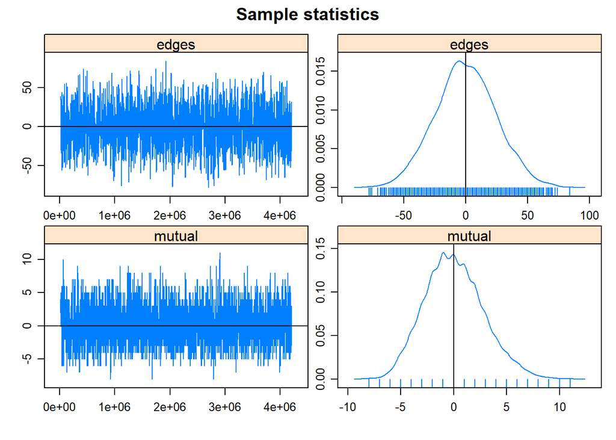

[output not shown]

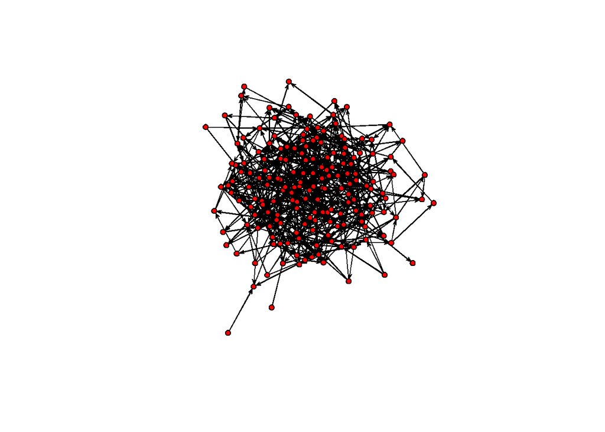

```r
plot(simnet1)
```

```r
#m2
m2.sim=simulate(m2,nsim=100);
simnet2=m2.sim[[1]]
mcmc.diagnostics(m2)
```

```
## Sample statistics summary:
##
## Iterations = 16384:4209664
## Thinning interval = 1024
## Number of chains = 1
## Sample size per chain = 4096
##
## 1. Empirical mean and standard deviation for each variable,
##    plus standard error of the mean:
##
##           Mean     SD Naive SE Time-series SE
## edges  0.72290 17.055  0.26648        0.32451
## mutual 0.08472  2.826  0.04416        0.05088
##
## 2. Quantiles for each variable:
##
##        2.5% 25% 50% 75% 97.5%
## edges   -32 -11   1  12    35
## mutual   -5  -2   0   2     6
##
##
## Sample statistics cross-correlations:
##            edges    mutual
## edges  1.0000000 0.3182861
## mutual 0.3182861 1.0000000
##
## Sample statistics auto-correlation:
## Chain 1
##                 edges      mutual
## Lag 0     1.000000000  1.00000000
## Lag 1024  0.194387184  0.13229835
## Lag 2048  0.045069730  0.04776379
## Lag 3072  0.028313224  0.02463865
## Lag 4096  0.013160107 -0.03017986
## Lag 5120 -0.003845711  0.00274344
##
## Sample statistics burn-in diagnostic (Geweke):
## Chain 1
##
## Fraction in 1st window = 0.1
## Fraction in 2nd window = 0.5
##
##    edges   mutual
##  0.24647 -0.04151
##
## Individual P-values (lower = worse):
##     edges    mutual
## 0.8053169 0.9668897
## Joint P-value (lower = worse):  0.9623031 .
```

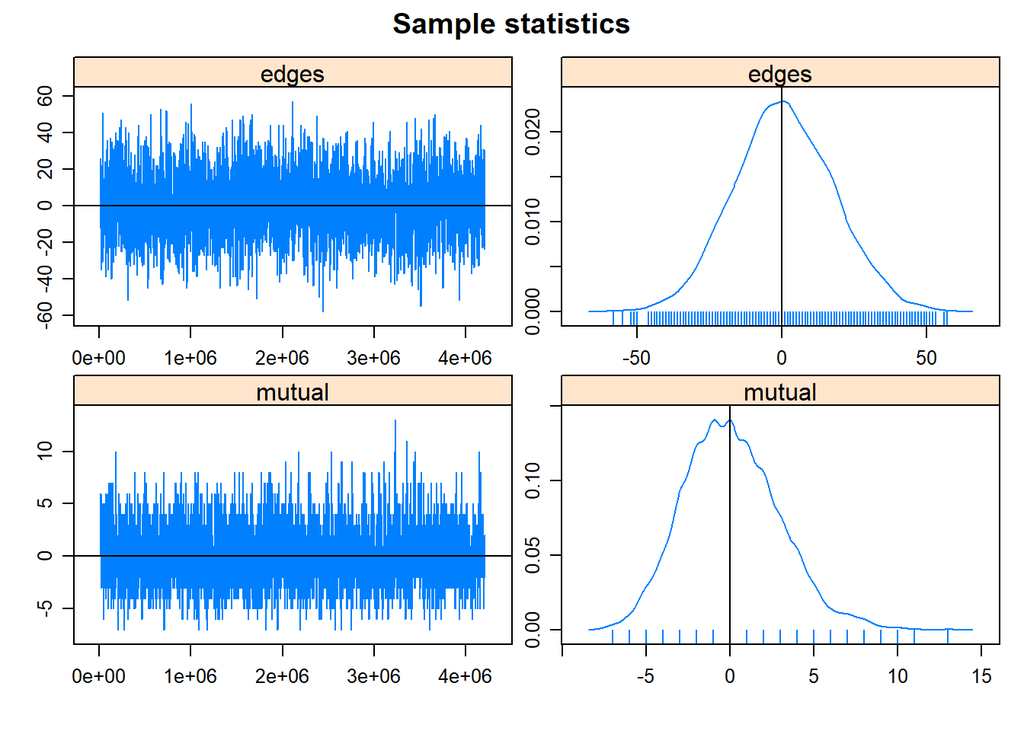

[output not shown]

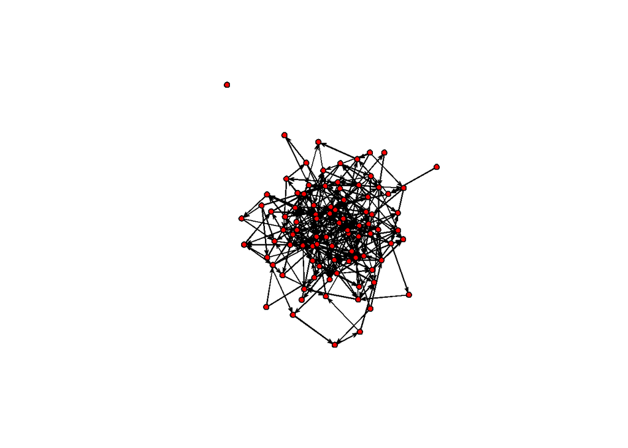

```r
plot(simnet2)
```

```r
#m3 I think this one is the best model
m3.sim=simulate(m3,nsim=100);
simnet3=m3.sim[[1]]
mcmc.diagnostics(m2)
```

[output not shown]

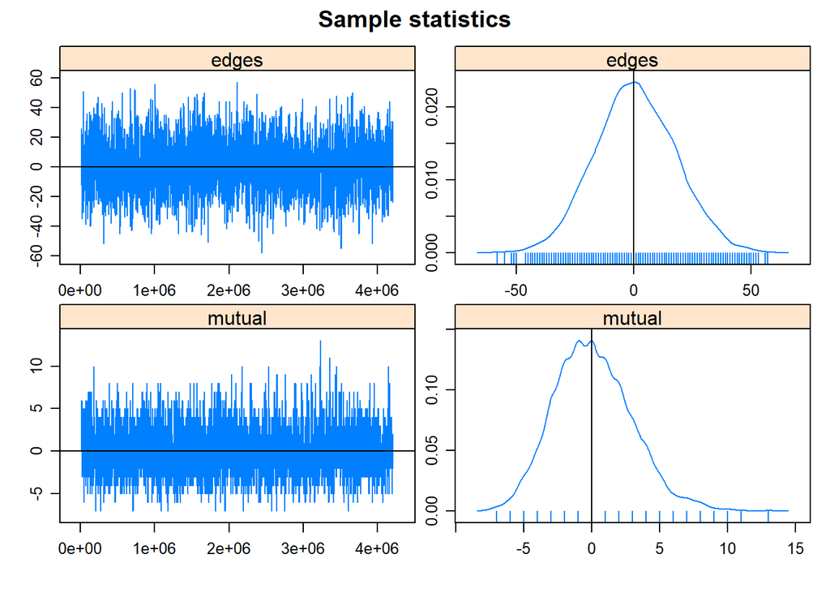

[output not shown]

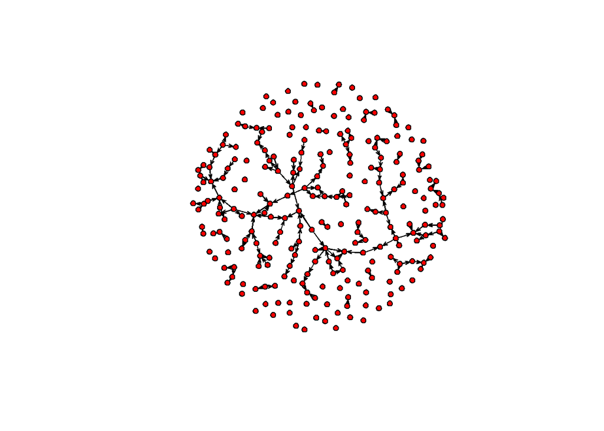

```r
plot(simnet3)
```

```r
#m4_1
m4_1.sim=simulate(m4_1,nsim=100);
simnet4_1=m4_1.sim[[1]]
mcmc.diagnostics(m4_1)
```

```
## Sample statistics summary:
##
## Iterations = 16384:4209664
## Thinning interval = 1024
## Number of chains = 1
## Sample size per chain = 4096
##
## 1. Empirical mean and standard deviation for each variable,
##    plus standard error of the mean:
##
##                         Mean        SD  Naive SE Time-series SE
## edges              3.833e-01 1.012e+01 1.582e-01      1.582e-01
## absdiff.traction.y 9.089e+06 2.023e+08 3.161e+06      3.245e+06
##
## 2. Quantiles for each variable:
##
##                          2.5%        25%     50%       75%     97.5%
## edges                     -19         -7       0         7        20
## absdiff.traction.y -377565150 -134845375 -158448 135428492 404466183
##
##
## Sample statistics cross-correlations:
##                        edges absdiff.traction.y
## edges              1.0000000          0.7342047
## absdiff.traction.y 0.7342047          1.0000000
##
## Sample statistics auto-correlation:
## Chain 1
##                 edges absdiff.traction.y
## Lag 0     1.000000000        1.000000000
## Lag 1024  0.010330301        0.025898716
## Lag 2048  0.020835321        0.009705633
## Lag 3072  0.008264437       -0.019142322
## Lag 4096  0.010996557        0.016415896
## Lag 5120 -0.010749489        0.012615483
##
## Sample statistics burn-in diagnostic (Geweke):
## Chain 1
##
## Fraction in 1st window = 0.1
## Fraction in 2nd window = 0.5
##
##              edges absdiff.traction.y
##             0.8557            -0.9229
##
## Individual P-values (lower = worse):
##              edges absdiff.traction.y
##          0.3921403          0.3560847
## Joint P-value (lower = worse):  0.6377347 .
```

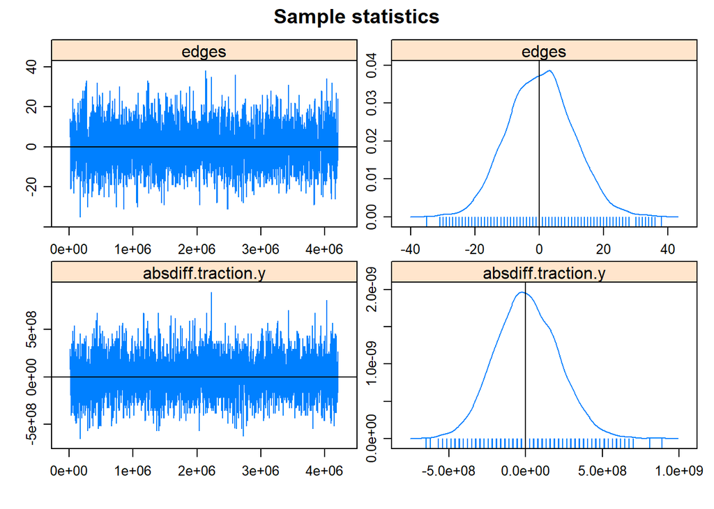

[output not shown]

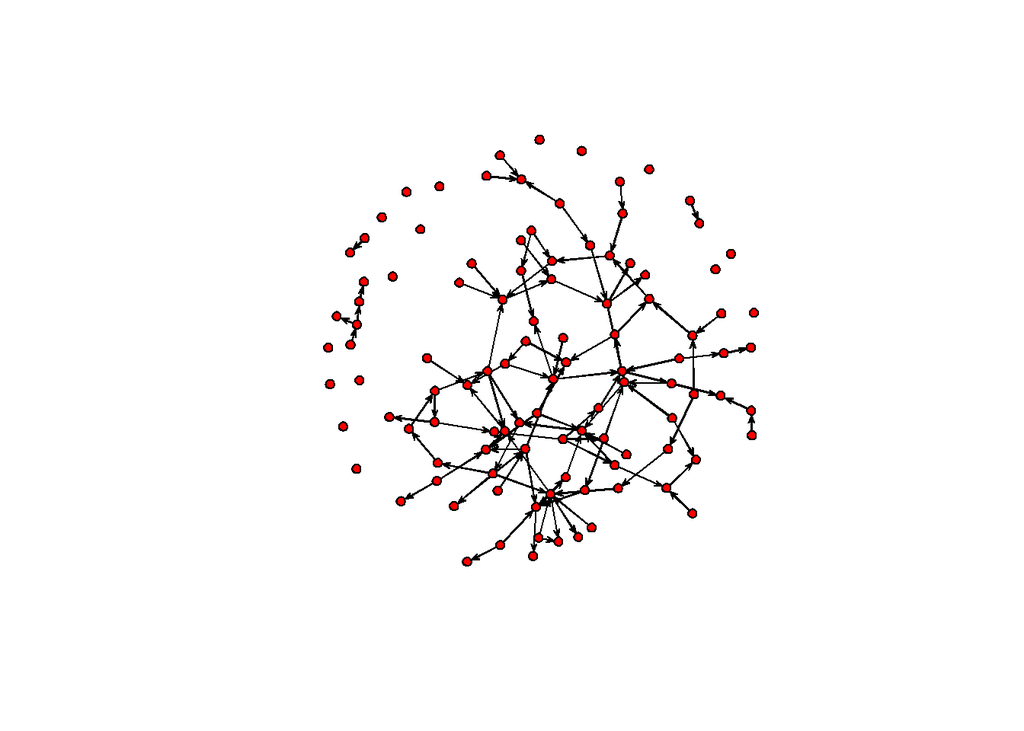

```r
plot(simnet4_1)
```

```r
#m4
m4.sim=simulate(m4,nsim=100);
simnet4=m4.sim[[1]]
mcmc.diagnostics(m4)
```

```
## Sample statistics summary:
##
## Iterations = 16384:4209664
## Thinning interval = 1024
## Number of chains = 1
## Sample size per chain = 4096
##
## 1. Empirical mean and standard deviation for each variable,
##    plus standard error of the mean:
##
##               Mean    SD Naive SE Time-series SE
## edges      -0.3174 8.752   0.1368         0.1368
## edgecov.Q3  0.0000 0.000   0.0000         0.0000
##
## 2. Quantiles for each variable:
##
##            2.5% 25% 50% 75% 97.5%
## edges       -17  -6   0   5    18
## edgecov.Q3    0   0   0   0     0
##
##
## Sample statistics cross-correlations:
```

```
##            edges edgecov.Q3
## edges          1         NA
## edgecov.Q3    NA          1
##
## Sample statistics auto-correlation:
## Chain 1
##                 edges edgecov.Q3
## Lag 0     1.000000000        NaN
## Lag 1024  0.003881500        NaN
## Lag 2048  0.004420662        NaN
## Lag 3072 -0.013848689        NaN
## Lag 4096  0.007042146        NaN
## Lag 5120  0.001331760        NaN
##
## Sample statistics burn-in diagnostic (Geweke):
```

```
## Chain 1
##
## Fraction in 1st window = 0.1
## Fraction in 2nd window = 0.5
##
##      edges edgecov.Q3
##     0.2294        NaN
##
## Individual P-values (lower = worse):
##      edges edgecov.Q3
##  0.8185816        NaN
## Joint P-value (lower = worse):  0.8241573 .
```

[figure not shown]

[output not shown]

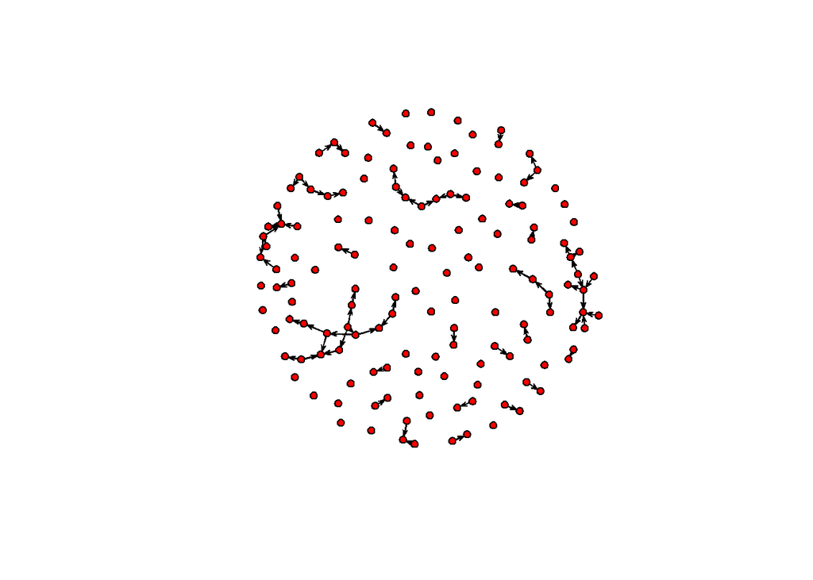

```r
plot(simnet4)
```

```r
#m5
m5.sim=simulate(m4,nsim=100);
simnet5=m5.sim[[1]]
mcmc.diagnostics(m5)
```

```
## Sample statistics summary:
##
## Iterations = 16384:4209664
## Thinning interval = 1024
## Number of chains = 1
## Sample size per chain = 4096
##
## 1. Empirical mean and standard deviation for each variable,
##    plus standard error of the mean:
##
##                          Mean        SD  Naive SE Time-series SE
## edges              -6.421e-01 1.644e+01 2.568e-01      2.903e-01
## absdiff.traction.p -1.723e+07 3.265e+08 5.102e+06      6.172e+06
##
## 2. Quantiles for each variable:
##
##                          2.5%        25%       50%       75%     97.5%
## edges                     -33        -12        -1        11 3.162e+01
## absdiff.traction.p -644791071 -245281533 -19705238 201262572 6.201e+08
##
##
## Sample statistics cross-correlations:
##                        edges absdiff.traction.p
## edges              1.0000000          0.8093339
## absdiff.traction.p 0.8093339          1.0000000
##
## Sample statistics auto-correlation:
## Chain 1
##                 edges absdiff.traction.p
## Lag 0     1.000000000        1.000000000
## Lag 1024  0.174893720        0.188028396
## Lag 2048  0.024806426        0.024764571
## Lag 3072  0.008967026        0.023880713
## Lag 4096 -0.009907480        0.008188367
## Lag 5120 -0.044435485       -0.028164410
##
## Sample statistics burn-in diagnostic (Geweke):
## Chain 1
##
## Fraction in 1st window = 0.1
## Fraction in 2nd window = 0.5
##
##              edges absdiff.traction.p
##            -0.4705            -0.4706
##
## Individual P-values (lower = worse):
##              edges absdiff.traction.p
##          0.6379906          0.6379368
## Joint P-value (lower = worse):  0.9022723 .
```

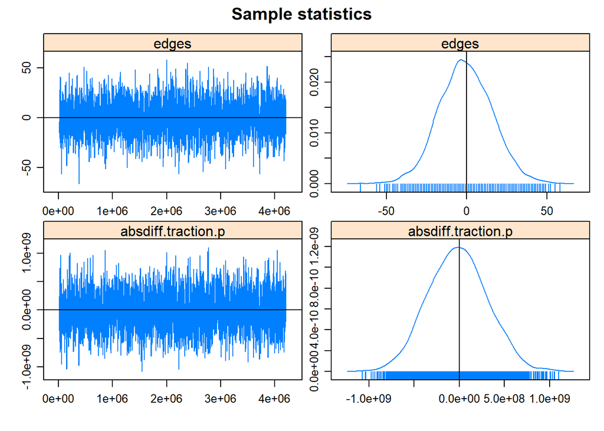

[output not shown]

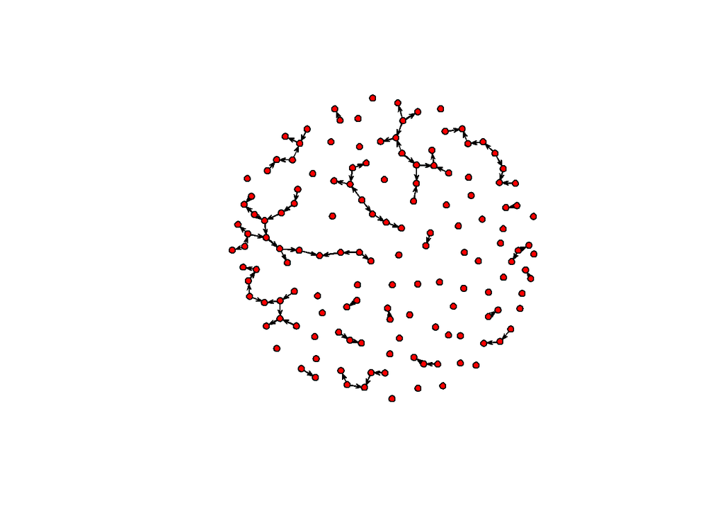

```r
plot(simnet5)
```

#Extra challenge problem RSiena provides a similar function to ERGM, but is more tailored for longitudinal data. Re-run the longitudinal models above (Questions 3, 4) using RSiena to determine if RSiena and ERGM produce similar results.

```r
library(RSiena)
```